# Exercise solutions: Section 8.8

Author

Rob J Hyndman and George Athanasopoulos

# fpp3 8.8, Ex5

> Data set `global_economy` contains the annual Exports from many countries. Select one country to analyse.
> 1. Plot the Exports series and discuss the main features of the data.

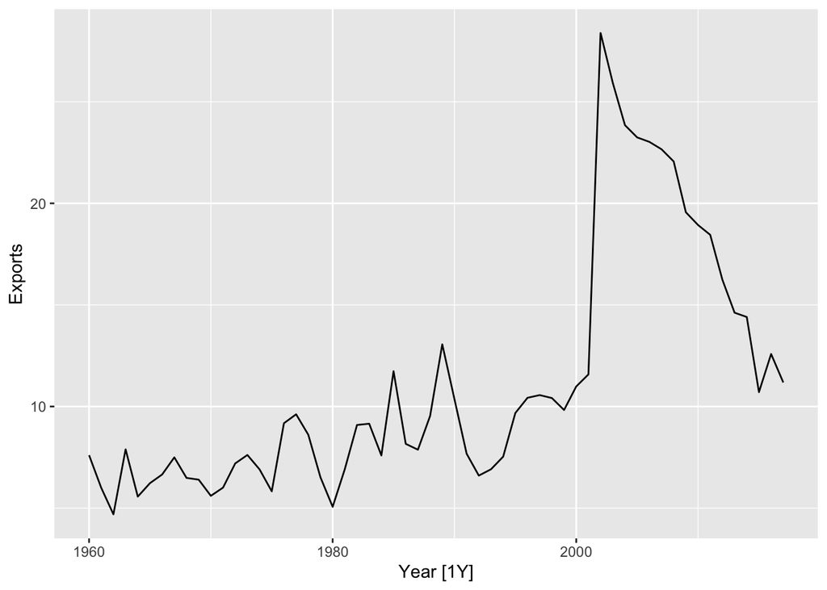

```r
global_economy |>
  filter(Country == "Argentina") |>
  autoplot(Exports)
```

There is a huge jump in Exports in 2002, due to the deregulation of the Argentinian peso. Since then, Exports (as a percentage of GDP) has gradually returned to 1990 levels.

> 2. Use an ETS(A,N,N) model to forecast the series, and plot the forecasts.

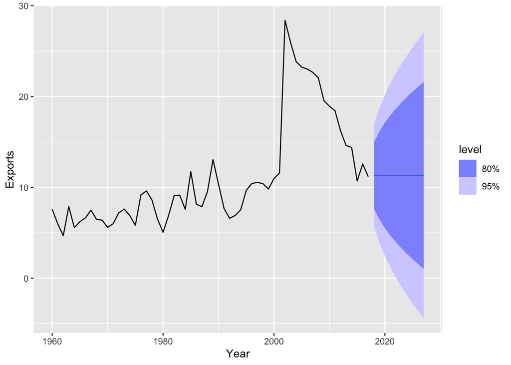

```r
etsANN <- global_economy |>
  filter(Country == "Argentina") |>
  model(ETS(Exports ~ error("A") + trend("N") + season("N")))
etsANN |>
  forecast(h = 10) |>
  autoplot(global_economy)
```

> 3. Compute the RMSE values for the training data.

```r
accuracy(etsANN) |> select(RMSE)
```

```
# A tibble: 1 × 1
   RMSE
  <dbl>
1  2.78
```

> 4. Compare the results to those from an ETS(A,A,N) model. (Remember that the trended model is using one more parameter than the simpler model.) Discuss the merits of the two forecasting methods for this data set.

```r
fit <- global_economy |>
  filter(Country == "Argentina") |>
  model(
    ses = ETS(Exports ~ error("A") + trend("N") + season("N")),
    holt = ETS(Exports ~ error("A") + trend("A") + season("N"))
  )
accuracy(fit)
```

```
# A tibble: 2 × 11
  Country   .model .type         ME  RMSE   MAE   MPE  MAPE  MASE RMSSE    ACF1
  <fct>     <chr>  <chr>      <dbl> <dbl> <dbl> <dbl> <dbl> <dbl> <dbl>   <dbl>
1 Argentina ses    Training 0.0762   2.78  1.62 -1.73  15.7 0.983 0.986 0.00902
2 Argentina holt   Training 0.00795  2.78  1.64 -2.51  15.9 0.994 0.986 0.0271
```

There is very little difference in training RMSE between these models. So the extra parameter is not doing much.

> 5. Compare the forecasts from both methods. Which do you think is best?

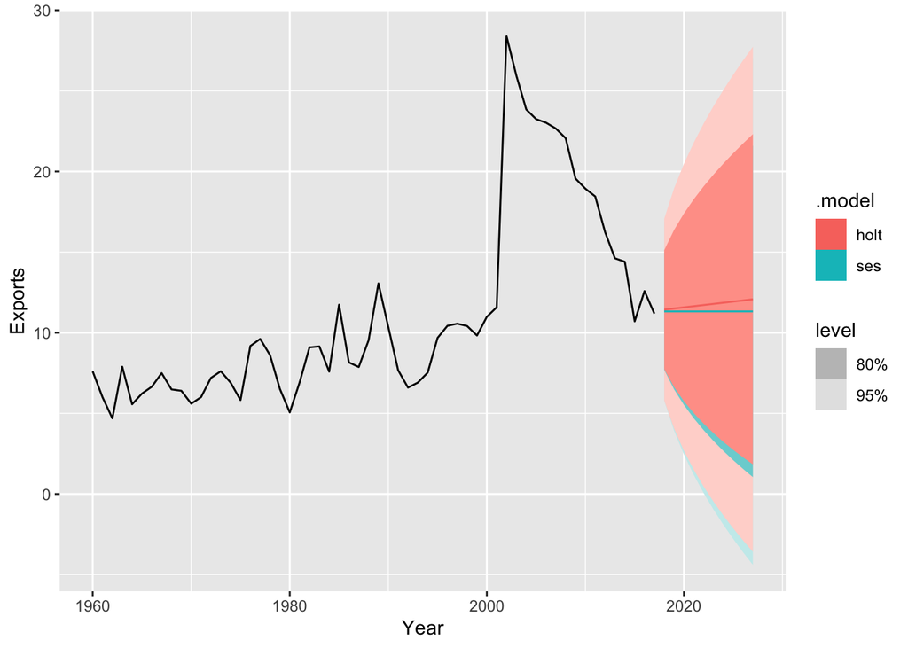

```r
fit |>
  forecast(h = 10) |>
  autoplot(global_economy)
```

- The forecasts are similar. In this case, the *simpler* model is preferred.
> 6. Calculate a 95% prediction interval for the first forecast for each series, using the RMSE values and assuming normal errors. Compare your intervals with those produced using R.
1. standard error. (from RMSE)
2. mean (from forecast)

```r
s <- accuracy(fit) |> pull(RMSE)
yhat <- forecast(fit, h = 1) |> pull(.mean)
# SES
yhat[1] + c(-1, 1) * qnorm(0.975) * s[1]
```

```
[1]  5.882074 16.764136
```

```r
# Holt
yhat[2] + c(-1, 1) * qnorm(0.975) * s[2]
```

```
[1]  5.989515 16.872908
```

```r
fit |>
  forecast(h = 1) |>
  mutate(PI = hilo(Exports, level = 95))
```

```
# A fable: 2 x 6 [1Y]
# Key:     Country, .model [2]
  Country   .model  Year
  <fct>     <chr>  <dbl>
1 Argentina ses     2018
2 Argentina holt    2018
# ℹ 3 more variables: Exports <dist>, .mean <dbl>, PI <hilo>
```

```r
sse <- augment(fit) |>
  as_tibble() |>
  group_by(.model) |>
  summarise(s = sum(.resid^2)) |>
  pull(s)

n <- global_economy |>
  filter(Country == "Argentina") |>
    nrow()

# sse method= alpha, level=> 2
# holt linear = alpha, level, trend, b => 4

s <- sqrt(sse / (n - c(2, 4)))

# SES
yhat[1] + c(-1, 1) * qnorm(0.975) * s[1]
```

```
[1]  5.785088 16.861122
```

```r
# Holt
yhat[2] + c(-1, 1) * qnorm(0.975) * s[2]
```

```
[1]  5.79226 17.07016
```